hgraph module - simul module - paper figures

# Short introduction into the hgraph module

Detlef Groth, Detlef Groth, University of Potsdam, Germany

2023-02-09

## Introduction

The `hgraph` object offers a few functions to deal with adjacency matrices which are for instance created from the `simul` module. This module is a simple R environment and can be inspected therefor using the `ls` function.

```r
library(hanna)
ls(hgraph)
```

```
##  [1] "average_path_length" "colors"              "d2u"
##  [4] "degree"              "eccentricity"        "graph"
##  [7] "layout"              "plot"                "shortest_paths"
## [10] "triads"
```

There are as well a few private functions which should not be used directly be the programmer.

```r
ls(hgraph,all=TRUE)
```

```
##  [1] ".Components"         ".Connect"            "average_path_length"
##  [4] "colors"              "d2u"                 "degree"
##  [7] "eccentricity"        "graph"               "layout"
## [10] "plot"                "shortest_paths"      "triads"
```

These private functions are starting with a dot at the beginning.

## Creating an example graph

There is as well a function which can be used to create some example graphs. Here an example were we create a so called Werner graph.

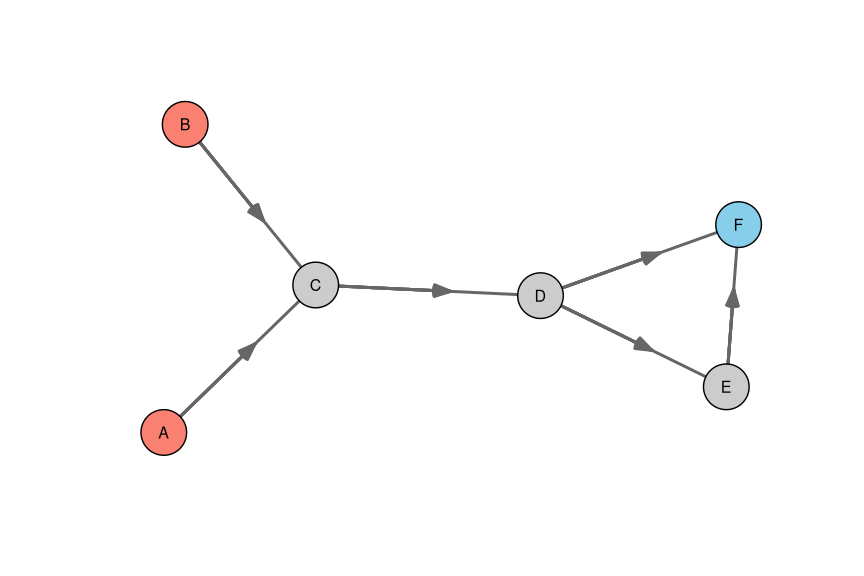

```r
W=hgraph$graph()
cols=hgraph$colors(W)
hgraph$plot(W,vertex.color=cols)
```

Let’s create a larger random graph here:

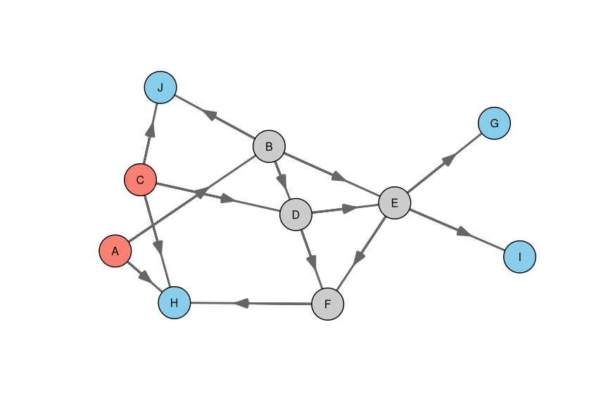

```r
set.seed(124)
R=hgraph$graph(type="random",nodes=10, edges=14)
cols=hgraph$colors(R)
hgraph$plot(R,vertex.color=cols)
```

## Graph conversion

You can as well create undirected graphs, where the edges have no direction out of directed graphs.

```r
R
```

```
##   A B C D E F G H I J
## A 0 1 0 0 0 0 0 1 0 0
## B 0 0 0 1 1 0 0 0 0 1
## C 0 0 0 1 0 0 0 1 0 1
## D 0 0 0 0 1 1 0 0 0 0
## E 0 0 0 0 0 1 1 0 1 0
## F 0 0 0 0 0 0 0 1 0 0
## G 0 0 0 0 0 0 0 0 0 0
## H 0 0 0 0 0 0 0 0 0 0
## I 0 0 0 0 0 0 0 0 0 0
## J 0 0 0 0 0 0 0 0 0 0
## attr(,"class")
## [1] "graph"  "matrix"
```

```r
U=hgraph$d2u(R)
U
```

```
##   A B C D E F G H I J
## A 0 1 0 0 0 0 0 1 0 0
## B 1 0 0 1 1 0 0 0 0 1
## C 0 0 0 1 0 0 0 1 0 1
## D 0 1 1 0 1 1 0 0 0 0
## E 0 1 0 1 0 1 1 0 1 0
## F 0 0 0 1 1 0 0 1 0 0
## G 0 0 0 0 1 0 0 0 0 0
## H 1 0 1 0 0 1 0 0 0 0
## I 0 0 0 0 1 0 0 0 0 0
## J 0 1 1 0 0 0 0 0 0 0
## attr(,"class")
## [1] "graph"  "matrix"
```

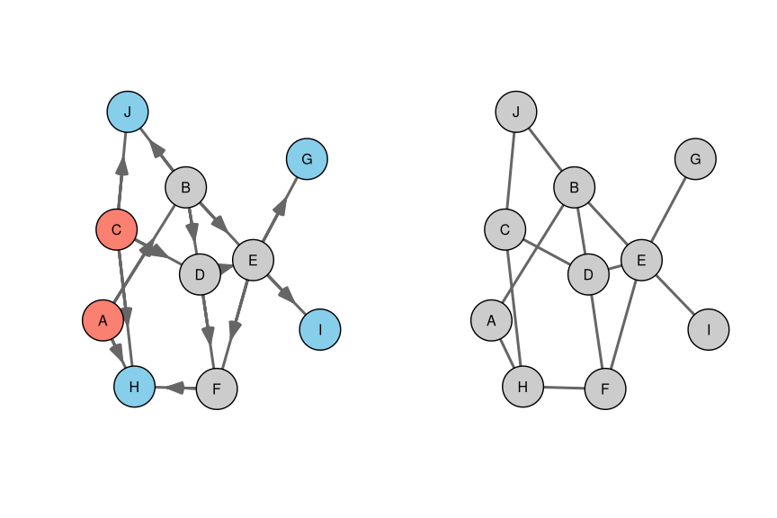

```r
lay=hgraph$layout(U)
par(mfrow=c(1,2))
plot(R,vertex.color=cols,layout=lay)
plot(U,layout=lay)
```

## Graph information

We can extract various information about graphs and their nodes. For instance how many edges has every node using the degree function or what is the length of the shortest paths between all nodes. Here some example code:

```r
hgraph$degree(U)
```

```
## A B C D E F G H I J
## 2 4 3 4 5 3 1 3 1 2
```

```r
hgraph$shortest_paths(U)
```

```
##   A B C D E F G H I J
## A 0 1 2 2 2 2 3 1 3 2
## B 1 0 2 1 1 2 2 2 2 1
## C 2 2 0 1 2 2 3 1 3 1
## D 2 1 1 0 1 1 2 2 2 2
## E 2 1 2 1 0 1 1 2 1 2
## F 2 2 2 1 1 0 2 1 2 3
## G 3 2 3 2 1 2 0 3 2 3
## H 1 2 1 2 2 1 3 0 3 2
## I 3 2 3 2 1 2 2 3 0 3
## J 2 1 1 2 2 3 3 2 3 0
## attr(,"class")
## [1] "graph"  "matrix"
```

For an graph with several components the distance can be as well `Inf(inite)`. Let’s remove the edge between the nodes G and E for example and then recalculate the distances.

```r
U2=U
U2[c('G','E'),c('G','E')]=0
hgraph$shortest_paths(U2)
```

```
##     A   B   C   D   E   F   G   H   I   J
## A   0   1   2   2   2   2 Inf   1   3   2
## B   1   0   2   1   1   2 Inf   2   2   1
## C   2   2   0   1   2   2 Inf   1   3   1
## D   2   1   1   0   1   1 Inf   2   2   2
## E   2   1   2   1   0   1 Inf   2   1   2
## F   2   2   2   1   1   0 Inf   1   2   3
## G Inf Inf Inf Inf Inf Inf   0 Inf Inf Inf
## H   1   2   1   2   2   1 Inf   0   3   2
## I   3   2   3   2   1   2 Inf   3   0   3
## J   2   1   1   2   2   3 Inf   2   3   0
## attr(,"class")
## [1] "graph"  "matrix"
```

If you need more functionality for working with graphs I suggest you use the nice `igraph` package which is available for R. This class is only intended to be a helper object for the `simil` object for extracting graph related information and for visualization.